# Reproducible Research Week 2, Project 1: Exploratory Analysis of Personal Monitoring Data

Joseph Rimando

1/30/2022

# Load and preprocess the data: convert the date character strings into date format

```r
activity<-read.csv("activity.csv")
library(lubridate,quietly = TRUE)
activity$date<-ymd(activity$date)
```

# What is the mean total number of steps taken per day?

### Make a histogram of the total number of steps taken each day

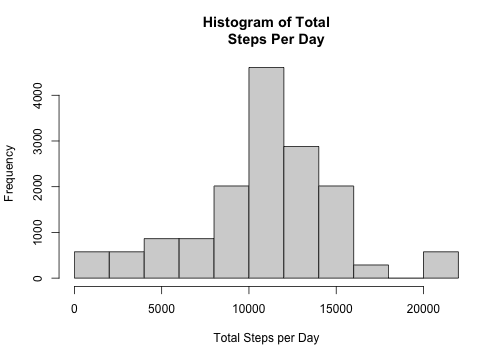

```r
activity$totalsteps_day<-ave(activity$steps,
        activity$date, FUN = sum, na.rm=TRUE)
hist(activity$totalsteps_day, main="Histogram of Total
     Steps Per Day", xlab = "Total Steps per Day")
```

### Calculate and report the mean (10766.19) and median (10765) total number of steps taken per day.

```r
mean(activity$totalsteps_day, na.rm = TRUE)
```

```
## [1] 10766.19
```

```r
median(activity$totalsteps_day, na.rm = TRUE)
```

```
## [1] 10765
```

# What is the average daily activity pattern?

### Make a time series plot (i.e. type = “l”) of the 5-minute interval (x-axis) and the average number of steps taken, averaged across all days (y-axis)

#### Calculate the average number steps taken for each 5-minute interval and create a new column in database

```r
library(tidyverse, quietly = TRUE)
activity$interval<-as.factor(activity$interval)
avgsteps_interval<-tapply(activity$steps,activity$interval, mean, na.rm=TRUE)
avgsteps_interval<-as.data.frame(avgsteps_interval)
avgsteps_interval<-avgsteps_interval %>% rownames_to_column(var="interval")
activity_asi<-inner_join(activity,avgsteps_interval,by="interval")
```

#### Plot the data

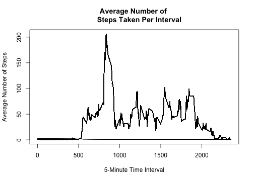

```r
plot(activity_asi$interval, activity_asi$avgsteps_interval, type="l", main = "Average Number of
     Steps Taken Per Interval",
     xlab = "5-Minute Time Interval", ylab = "Average Number of Steps")
```

### Which 5-minute interval, on average across all the days in the dataset, contains the maximum number of steps? (835)

```r
activity_asi_max<-activity_asi %>% filter(avgsteps_interval==max(activity_asi$avgsteps_interval))
activity_asi_max$interval
```

```
##  [1] "835" "835" "835" "835" "835" "835" "835" "835" "835" "835" "835" "835"
## [13] "835" "835" "835" "835" "835" "835" "835" "835" "835" "835" "835" "835"
## [25] "835" "835" "835" "835" "835" "835" "835" "835" "835" "835" "835" "835"
## [37] "835" "835" "835" "835" "835" "835" "835" "835" "835" "835" "835" "835"
## [49] "835" "835" "835" "835" "835" "835" "835" "835" "835" "835" "835" "835"
## [61] "835"
```

# Imputing missing values: Note that there are a number of days/intervals where ther are missing values (coded as NA). The presence of missing days may introduce bias into some calculations or summaries of the data.

### Calculate and report the total number of missing values in the dataset(i.e. the total number of rows with NAs).

```r
activity_noNA<-activity %>% filter(is.na(steps))
nrow(activity_noNA)
```

```
## [1] 2304
```

### Devise a strategy for filling in all of the missing values in the dataset. I will replace NA values with the mean for that 5-minute interval.

### Create a new dataset that is equal to the original dataset but with the missing data filled in.

```r
activity_asi_imputed<-activity_asi
activity_asi_imputed$steps<-
        coalesce(activity_asi_imputed$steps,
        activity_asi_imputed$avgsteps_interval)
```

### Make a histogram of the total number of steps taken each day.

#### Recalculate total number of steps taken per day and add it to the dataframe.

```r
activity_asi_imputed<-activity_asi_imputed[,-4]
activity_asi_imputed$totalsteps_day<-
        ave(activity_asi_imputed$steps,
        activity_asi_imputed$date, FUN = sum)
```

#### Plot the histogram with the imputed data

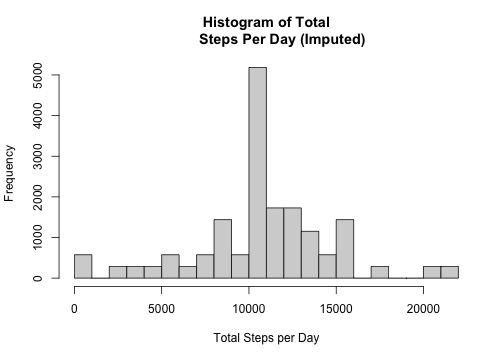

```r
hist(activity_asi_imputed$totalsteps_day,
        main="Histogram of Total
        Steps Per Day (Imputed)",
        xlab = "Total Steps per Day")
```

### Cacluate and report the mean (10766.19) and median (10766.19) total number of steps taken per day.

```r
mean(activity_asi_imputed$totalsteps_day)
```

```
## [1] 10766.19
```

```r
median(activity_asi_imputed$totalsteps_day)
```

```
## [1] 10766.19
```

### Do these values differ from the estimates from the first part of the assignment? They do not significantly differ.

### What is the impact of imputing missing data on the estimates of the total daily number of steps? There is no meaningful impact.

# Are these differences in activity patterns between weekdays and weekends? For this part, the weekdays() function may be of some help here. Use the dataset with the filled-in missing values for this part.

### Create a new factor variable in the dataset with two levels - “weekday” and “weekend” indicating wheter the date is a weekday or weekend day.

```r
activity_asi_imputed<-activity_asi_imputed %>% mutate(dotw = weekdays(date))
weekday<-c("Monday", "Tuesday", "Wednesday", "Thursday", "Friday")
weekend<-c("Saturday", "Sunday")
weekday_vector<-which(activity_asi_imputed$dotw %in% weekday)
activity_asi_imputed$daytype[weekday_vector]<-"Weekday"
weekend_vector<-which(activity_asi_imputed$dotw %in% weekend)
activity_asi_imputed$daytype[weekend_vector]<-"Weekend"
activity_asi_imputed$daytype<-as.factor(activity_asi_imputed$daytype)
```

### Make a panel plot containing a time series plot (i.e. type = “l”) of the 5-minute interval (x-axis) and the average number of steps taken, averaged across all weekday days or weekend days (y-axis).

#### First, calcluate average steps per interval for weekdays versus weekends

```r
activity_asi_imputed$avgsteps_interval_daytype[weekday_vector]<-
        ave(activity_asi_imputed$steps[weekday_vector],
        activity_asi_imputed$interval)
activity_asi_imputed$avgsteps_interval_daytype[weekend_vector]<-
        ave(activity_asi_imputed$steps[weekend_vector],
        activity_asi_imputed$interval)
```

#### Make the panel plot

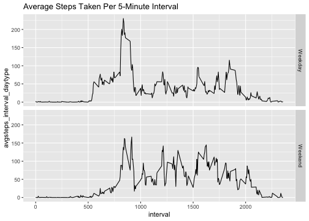

```r
activity_asi_imputed$interval<-as.numeric(activity_asi_imputed$interval)
ggplot(data=activity_asi_imputed, aes(interval, avgsteps_interval_daytype)) + geom_line() +
        facet_grid(daytype~.) + ggtitle("Average Steps Taken Per 5-Minute Interval")
```